# Module 2: Introduction to Numpy and Pandas

The following tutorial contains examples of using the numpy and pandas library modules. The notebook can be downloaded from http://www.cse.msu.edu/~ptan/dmbook/tutorials/tutorial2/tutorial2.ipynb. Read the step-by-step instructions below carefully. To execute the code, click on the cell and press the SHIFT-ENTER keys simultaneously.

## 2.1 Introduction to Numpy

Numpy, which stands for numerical Python, is a Python library package to support numerical computations. The basic data structure in numpy is a multi-dimensional array object called ndarray. Numpy provides a suite of functions that can efficiently manipulate elements of the ndarray.

### 2.1.1 Creating ndarray

An ndarray can be created from a list or tuple object.

```python
import numpy as np

oneDim = np.array([1.0,2,3,4,5])   # a 1-dimensional array (vector)
print(oneDim)
print("#Dimensions =", oneDim.ndim)
print("Dimension =", oneDim.shape)
print("Size =", oneDim.size)
print("Array type =", oneDim.dtype)

twoDim = np.array([[1,2],[3,4],[5,6],[7,8]])  # a two-dimensional array (matrix)
print(twoDim)
print("#Dimensions =", twoDim.ndim)
print("Dimension =", twoDim.shape)
print("Size =", twoDim.size)
print("Array type =", twoDim.dtype)

arrFromTuple = np.array([(1,'a',3.0),(2,'b',3.5)])  # create ndarray from tuple
print(arrFromTuple)
print("#Dimensions =", arrFromTuple.ndim)
print("Dimension =", arrFromTuple.shape)
print("Size =", arrFromTuple.size)
```

```
[1. 2. 3. 4. 5.]
#Dimensions = 1
Dimension = (5,)
Size = 5
Array type = float64
[[1 2]
 [3 4]
 [5 6]
 [7 8]]
#Dimensions = 2
Dimension = (4, 2)
Size = 8
Array type = int64
[['1' 'a' '3.0']
 ['2' 'b' '3.5']]
#Dimensions = 2
Dimension = (2, 3)
Size = 6
```

There are several built-in functions in numpy that can be used to create ndarrays

```python
print(np.random.rand(5))      # random numbers from a uniform distribution between [0,1]
print(np.random.randn(5))     # random numbers from a normal distribution
print(np.arange(-10,10,2))    # similar to range, but returns ndarray instead of list
print(np.arange(12).reshape(3,4))  # reshape to a matrix
print(np.linspace(0,1,10))    # split interval [0,1] into 10 equally separated values
print(np.logspace(-3,3,7))    # create ndarray with values from 10^-3 to 10^3
```

```
[0.43852623 0.92573151 0.57182946 0.76585633 0.04172568]
[-0.50732703 -1.20544683  1.08801609 -0.17300401  1.19399187]
[-10  -8  -6  -4  -2   0   2   4   6   8]
[[ 0  1  2  3]
 [ 4  5  6  7]
 [ 8  9 10 11]]
[0.         0.11111111 0.22222222 0.33333333 0.44444444 0.55555556
 0.66666667 0.77777778 0.88888889 1.        ]
[1.e-03 1.e-02 1.e-01 1.e+00 1.e+01 1.e+02 1.e+03]
```

```python
print(np.zeros((2,3)))        # a matrix of zeros
print(np.ones((3,2)))         # a matrix of ones
print(np.eye(3))              # a 3 x 3 identity matrix
```

```
[[0. 0. 0.]
 [0. 0. 0.]]
[[1. 1.]
 [1. 1.]
 [1. 1.]]
[[1. 0. 0.]
 [0. 1. 0.]
 [0. 0. 1.]]
```

## 2.1.2 Element-wise Operations

You can apply standard operators such as addition and multiplication on each element of the ndarray.

```python
x = np.array([1,2,3,4,5])

print(x + 1)      # addition
print(x - 1)      # subtraction
print(x * 2)      # multiplication
print(x // 2)     # integer division
print(x ** 2)     # square
print(x % 2)      # modulo
print(1 / x)      # division
```

```
[2 3 4 5 6]
[0 1 2 3 4]
[ 2  4  6  8 10]
[0 1 1 2 2]
[ 1  4  9 16 25]
[1 0 1 0 1]
[1.         0.5        0.33333333 0.25       0.2       ]
```

```python
x = np.array([2,4,6,8,10])
y = np.array([1,2,3,4,5])

print(x + y)
print(x - y)
print(x * y)
print(x / y)
print(x // y)
print(x ** y)
```

```
[ 3  6  9 12 15]
[1 2 3 4 5]
[ 2  8 18 32 50]
[2. 2. 2. 2. 2.]
[2 2 2 2 2]
[     2     16    216   4096 100000]
```

## 2.1.3 Indexing and Slicing

There are various ways to select certain elements with an ndarray.

```python
x = np.arange(-5,5)
print(x)

y = x[3:5]     # y is a slice, i.e., pointer to a subarray in x
print(y)
y[:] = 1000    # modifying the value of y will change x
print(y)
print(x)

z = x[3:5].copy()   # makes a copy of the subarray
print(z)
z[:] = 500          # modifying the value of z will not affect x
print(z)
print(x)
```

```
[-5 -4 -3 -2 -1  0  1  2  3  4]
[-2 -1]
[1000 1000]
[  -5   -4   -3 1000 1000    0    1    2    3    4]
[1000 1000]
[500 500]
[  -5   -4   -3 1000 1000    0    1    2    3    4]
```

```python
my2dlist = [[1,2,3,4],[5,6,7,8],[9,10,11,12]]   # a 2-dim list
print(my2dlist)
print(my2dlist[2])        # access the third sublist
print(my2dlist[:][2])     # can't access third element of each sublist
# print(my2dlist[:,2])    # this will cause syntax error

my2darr = np.array(my2dlist)
print(my2darr)
print(my2darr[2][:])      # access the third row
print(my2darr[2,:])       # access the third row
print(my2darr[:][2])      # access the third row (similar to 2d list)
print(my2darr[:,2])       # access the third column
print(my2darr[:2,2:])     # access the first two rows & last two columns
```

```
[[1, 2, 3, 4], [5, 6, 7, 8], [9, 10, 11, 12]]
[9, 10, 11, 12]
[9, 10, 11, 12]
[[ 1  2  3  4]
 [ 5  6  7  8]
 [ 9 10 11 12]]
[ 9 10 11 12]
[ 9 10 11 12]
[ 9 10 11 12]
[ 3  7 11]
[[3 4]
 [7 8]]
```

ndarray also supports boolean indexing.

```python
my2darr = np.arange(1,13,1).reshape(3,4)
print(my2darr)

divBy3 = my2darr[my2darr % 3 == 0]
print(divBy3, type(divBy3))

divBy3LastRow = my2darr[2:, my2darr[2,:] % 3 == 0]
print(divBy3LastRow)
```

```
[[ 1  2  3  4]
 [ 5  6  7  8]
 [ 9 10 11 12]]
[ 3  6  9 12] <class 'numpy.ndarray'>
[[ 9 12]]
```

More indexing examples.

```python
my2darr = np.arange(1,13,1).reshape(4,3)
print(my2darr)

indices = [2,1,0,3]    # selected row indices
print(my2darr[indices,:])

rowIndex = [0,0,1,2,3]     # row index into my2darr
columnIndex = [0,2,0,1,2]  # column index into my2darr
print(my2darr[rowIndex,columnIndex])
```

```
[[ 1  2  3]
 [ 4  5  6]
 [ 7  8  9]
 [10 11 12]]
[[ 7  8  9]
 [ 4  5  6]
 [ 1  2  3]
 [10 11 12]]
[ 1  3  4  8 12]
```

## 2.1.4 Numpy Arithmetic and Statistical Functions

There are many built-in mathematical functions available for manipulating elements of nd-array.

```python
y = np.array([-1.4, 0.4, -3.2, 2.5, 3.4])    # generate a random vector
print(y)

print(np.abs(y))          # convert to absolute values
print(np.sqrt(abs(y)))    # apply square root to each element
print(np.sign(y))         # get the sign of each element
print(np.exp(y))          # apply exponentiation
print(np.sort(y))         # sort array
```

```
[-1.4  0.4 -3.2  2.5  3.4]
[1.4 0.4 3.2 2.5 3.4]
[1.18321596 0.63245553 1.78885438 1.58113883 1.84390889]
[-1.  1. -1.  1.  1.]
[ 0.24659696  1.4918247   0.0407622  12.18249396 29.96410005]
[-3.2 -1.4  0.4  2.5  3.4]
```

```python
x = np.arange(-2,3)
y = np.random.randn(5)
print(x)
print(y)

print(np.add(x,y))           # element-wise addition       x + y
print(np.subtract(x,y))      # element-wise subtraction    x - y
print(np.multiply(x,y))      # element-wise multiplication x * y
print(np.divide(x,y))        # element-wise division       x / y
print(np.maximum(x,y))       # element-wise maximum        max(x,y)
```

```
[-2 -1  0  1  2]
[ 1.97744852  1.5487389  -1.67787663 -0.59082607  0.75233559]
[-0.02255148  0.5487389  -1.67787663  0.40917393  2.75233559]
[-3.97744852 -2.5487389   1.67787663  1.59082607  1.24766441]
[-3.95489704 -1.5487389  -0.         -0.59082607  1.50467118]
[-1.01140433 -0.64568663 -0.         -1.69254549  2.65838812]
[1.97744852 1.5487389  0.         1.         2.        ]
```

```python
y = np.array([-3.2, -1.4, 0.4, 2.5, 3.4])    # generate a random vector
print(y)

print("Min =", np.min(y))             # min
print("Max =", np.max(y))             # max
print("Average =", np.mean(y))        # mean/average
print("Std deviation =", np.std(y))   # standard deviation
print("Sum =", np.sum(y))             # sum
```

```
[-3.2 -1.4  0.4  2.5  3.4]
Min = -3.2
Max = 3.4
Average = 0.34000000000000014
Std deviation = 2.432776191925595
Sum = 1.7000000000000006
```

## 2.1.5 Numpy linear algebra

Numpy provides many functions to support linear algebra operations.

```python
X = np.random.randn(2,3)    # create a 2 x 3 random matrix
print(X)
print(X.T)             # matrix transpose operation X^T

y = np.random.randn(3) # random vector
print(y)
print(X.dot(y))        # matrix-vector multiplication  X * y
print(X.dot(X.T))      # matrix-matrix multiplication  X * X^T
print(X.T.dot(X))      # matrix-matrix multiplication  X^T * X
```

```
[[ 0.87931186  1.53661958 -0.58757496]
 [ 1.31609131 -1.98502413 -1.71263378]]
[[ 0.87931186  1.31609131]
 [ 1.53661958 -1.98502413]
 [-0.58757496 -1.71263378]]
[-0.07301102 -1.93555379  1.02100147]
[-3.63832419  1.99743021]
[[ 3.47963341 -0.88667153]
 [-0.88667153  8.60553159]]
[[ 2.50528567 -1.26130518 -2.77064405]
 [-1.26130518  6.30152054  2.49674019]
 [-2.77064405  2.49674019  3.27835878]]
```

```python
X = np.random.randn(5,3)
print(X)

C = X.T.dot(X)               # C = X^T * X is a square matrix

invC = np.linalg.inv(C)      # inverse of a square matrix
print(invC)
detC = np.linalg.det(C)      # determinant of a square matrix
print(detC)
S, U = np.linalg.eig(C)      # eigenvalue S and eigenvector U of a square matrix
print(S)
print(U)
```

```
[[-1.81440348  2.04165197  0.67243988]
 [-1.33498007  0.04478968  0.24934003]
 [-0.02005211 -1.44755986 -1.53086532]
 [ 0.21210365 -0.33411807  1.49953705]
 [ 0.38514136  1.95800799  0.03822785]]
[[ 0.23032276  0.06465471  0.01345991]
 [ 0.06465471  0.13952249 -0.07163838]
 [ 0.01345991 -0.07163838  0.24342039]]
182.72122310322538
[13.09594829  4.02300123  3.46818197]
[[-0.38532401  0.81695512 -0.42908012]
 [ 0.83644438  0.11283603 -0.53631039]
 [ 0.38972582  0.56555492  0.72681595]]
```

## 2.2 Introduction to Pandas

Pandas provide two convenient data structures for storing and manipulating data--Series and DataFrame. A Series is similar to a one-dimensional array whereas a DataFrame is more similar to representing a matrix or a spreadsheet table.

### 2.2.1 Series

A Series object consists of a one-dimensional array of values, whose elements can be referenced using an index array. A Series object can be created from a list, a numpy array, or a Python dictionary. You can apply most of the numpy functions on the Series object.

```python
from pandas import Series

s = Series([3.1, 2.4, -1.7, 0.2, -2.9, 4.5])   # creating a series from a list
print(s)
print('Values=', s.values)     # display values of the Series
print('Index=', s.index)       # display indices of the Series
```

```
0    3.1
1    2.4
2   -1.7
3    0.2
4   -2.9
5    4.5
dtype: float64
Values= [ 3.1  2.4 -1.7  0.2 -2.9  4.5]
Index= RangeIndex(start=0, stop=6, step=1)
```

```python
import numpy as np

s2 = Series(np.random.randn(6))  # creating a series from a numpy ndarray
print(s2)
print('Values=', s2.values)   # display values of the Series
print('Index=', s2.index)     # display indices of the Series
```

```
0    0.701134
1    0.358219
2    0.013450
3    0.234028
4   -0.482119
5   -2.956755
dtype: float64
Values= [ 0.70113368  0.35821867  0.01345003  0.23402845 -0.48211943 -2.95675541]
Index= RangeIndex(start=0, stop=6, step=1)
```

```python
s3 = Series([1.2,2.5,-2.2,3.1,-0.8,-3.2],
            index = ['Jan 1','Jan 2','Jan 3','Jan 4','Jan 5','Jan 6',])
print(s3)
print('Values=', s3.values)   # display values of the Series
print('Index=', s3.index)     # display indices of the Series
```

```
Jan 1    1.2
Jan 2    2.5
Jan 3   -2.2
Jan 4    3.1
Jan 5   -0.8
Jan 6   -3.2
dtype: float64
Values= [ 1.2  2.5 -2.2  3.1 -0.8 -3.2]
Index= Index(['Jan 1', 'Jan 2', 'Jan 3', 'Jan 4', 'Jan 5', 'Jan 6'], dtype='object')
```

```python
capitals = {'MI': 'Lansing', 'CA': 'Sacramento', 'TX': 'Austin', 'MN': 'St Paul'}

s4 = Series(capitals)   # creating a series from dictionary object
print(s4)
print('Values=', s4.values)   # display values of the Series
print('Index=', s4.index)     # display indices of the Series
```

```
MI       Lansing
CA    Sacramento
TX        Austin
MN       St Paul
dtype: object
Values= ['Lansing' 'Sacramento' 'Austin' 'St Paul']
Index= Index(['MI', 'CA', 'TX', 'MN'], dtype='object')
```

```python
s3 = Series([1.2,2.5,-2.2,3.1,-0.8,-3.2],
            index = ['Jan 1','Jan 2','Jan 3','Jan 4','Jan 5','Jan 6',])
print(s3)

# Accessing elements of a Series

print('\ns3[2]=', s3[2])        # display third element of the Series
print('s3[\'Jan 3\']=', s3['Jan 3'])   # indexing element of a Series

print('\ns3[1:3]=')             # display a slice of the Series
print(s3[1:3])
print('s3.iloc([1:3])=')      # display a slice of the Series
print(s3.iloc[1:3])
```

```
Jan 1    1.2
Jan 2    2.5
Jan 3   -2.2
Jan 4    3.1
Jan 5   -0.8
Jan 6   -3.2
dtype: float64

s3[2]= -2.2
s3['Jan 3']= -2.2

s3[1:3]=
Jan 2    2.5
Jan 3   -2.2
dtype: float64
s3.iloc([1:3])=
Jan 2    2.5
Jan 3   -2.2
dtype: float64
```

```python
print('shape =', s3.shape)  # get the dimension of the Series
print('size =', s3.size)    # get the # of elements of the Series
```

```
shape = (6,)
size = 6
```

```python
print(s3[s3 > 0])   # applying filter to select elements of the Series
```

```
Jan 1    1.2
Jan 2    2.5
Jan 4    3.1
dtype: float64
```

```python
print(s3 + 4)       # applying scalar operation on a numeric Series
print(s3 / 4)
```

```
Jan 1    5.2
Jan 2    6.5
Jan 3    1.8
Jan 4    7.1
Jan 5    3.2
Jan 6    0.8
dtype: float64
Jan 1    0.300
Jan 2    0.625
Jan 3   -0.550
Jan 4    0.775
Jan 5   -0.200
Jan 6   -0.800
dtype: float64
```

```python
print(np.log(s3 + 4))    # applying numpy math functions to a numeric Series
```

```
Jan 1    1.648659
Jan 2    1.871802
Jan 3    0.587787
Jan 4    1.960095
Jan 5    1.163151
Jan 6   -0.223144
dtype: float64
```

### 2.2.2 DataFrame

A DataFrame object is a tabular, spreadsheet-like data structure containing a collection of columns, each of which can be of different types (numeric, string, boolean, etc). Unlike Series, a DataFrame has distinct row and column indices. There are many ways to create a DataFrame object (e.g., from a dictionary, list of tuples, or even numpy's ndarrays).

```python
from pandas import DataFrame

cars = {'make': ['Ford', 'Honda', 'Toyota', 'Tesla'],
       'model': ['Taurus', 'Accord', 'Camry', 'Model S'],
       'MSRP': [27595, 23570, 23495, 68000]}
carData = DataFrame(cars)   # creating DataFrame from dictionary
carData                     # display the table
```

|  | make | model | MSRP |
| --- | --- | --- | --- |
| 0 | Ford | Taurus | 27595 |
| 1 | Honda | Accord | 23570 |
| 2 | Toyota | Camry | 23495 |
| 3 | Tesla | Model S | 68000 |

```python
print(carData.index)       # print the row indices
print(carData.columns)     # print the column indices
```

```
RangeIndex(start=0, stop=4, step=1)
Index(['make', 'model', 'MSRP'], dtype='object')
```

```python
carData2 = DataFrame(cars, index = [1,2,3,4])  # change the row index
carData2['year'] = 2018    # add column with same value
carData2['dealership'] = ['Courtesy Ford','Capital Honda','Spartan Toyota','N/A']
carData2                   # display table
```

|  | make | model | MSRP | year | dealership |
| --- | --- | --- | --- | --- | --- |
| 1 | Ford | Taurus | 27595 | 2018 | Courtesy Ford |
| 2 | Honda | Accord | 23570 | 2018 | Capital Honda |
| 3 | Toyota | Camry | 23495 | 2018 | Spartan Toyota |
| 4 | Tesla | Model S | 68000 | 2018 | N/A |

Creating DataFrame from a list of tuples.

```python
tuplelist = [(2011,45.1,32.4),(2012,42.4,34.5),(2013,47.2,39.2),
              (2014,44.2,31.4),(2015,39.9,29.8),(2016,41.5,36.7)]
columnNames = ['year','temp','precip']
weatherData = DataFrame(tuplelist, columns=columnNames)
weatherData
```

|  | year | temp | precip |
| --- | --- | --- | --- |
| 0 | 2011 | 45.1 | 32.4 |
| 1 | 2012 | 42.4 | 34.5 |
| 2 | 2013 | 47.2 | 39.2 |
| 3 | 2014 | 44.2 | 31.4 |
| 4 | 2015 | 39.9 | 29.8 |
| 5 | 2016 | 41.5 | 36.7 |

Creating DataFrame from numpy ndarray

```python
import numpy as np

npdata = np.random.randn(5,3)  # create a 5 by 3 random matrix
columnNames = ['x1','x2','x3']
data = DataFrame(npdata, columns=columnNames)
data
```

|  | x1 | x2 | x3 |
| --- | --- | --- | --- |
| 0 | 0.982826 | 0.358808 | -0.338967 |
| 1 | 0.628353 | 0.043097 | 0.520344 |
| 2 | -1.132584 | -0.612484 | -1.024973 |
| 3 | 0.108524 | 1.854649 | 0.042428 |
| 4 | 2.241099 | -0.741912 | 1.295421 |

The elements of a DataFrame can be accessed in many ways.

```python
# accessing an entire column will return a Series object

print(data['x2'])
print(type(data['x2']))
```

```
0    0.358808
1    0.043097
2   -0.612484
3    1.854649
4   -0.741912
Name: x2, dtype: float64
<class 'pandas.core.series.Series'>
```

```python
# accessing an entire row will return a Series object

print('Row 3 of data table:')
print(data.iloc[2])       # returns the 3rd row of DataFrame
print(type(data.iloc[2]))
print('\nRow 3 of car data table:')
print(carData2.iloc[2])   # row contains objects of different types
```

```
Row 3 of data table:
x1   -1.132584
x2   -0.612484
x3   -1.024973
Name: 2, dtype: float64
<class 'pandas.core.series.Series'>

Row 3 of car data table:
make                  Toyota
model                  Camry
MSRP                   23495
year                    2018
dealership    Spartan Toyota
Name: 3, dtype: object
```

```python
# accessing a specific element of the DataFrame

print(carData2.iloc[1,2])      # retrieving second row, third column
print(carData2.loc[1,'model']) # retrieving second row, column named 'model'

# accessing a slice of the DataFrame

print('carData2.iloc[1:3,1:3]=')
print(carData2.iloc[1:3,1:3])
```

```
23570
Taurus
carData2.iloc[1:3,1:3]=
    model   MSRP
2  Accord  23570
3   Camry  23495
```

```python
print('carData2.shape =', carData2.shape)
print('carData2.size =', carData2.size)
```

```
carData2.shape = (4, 5)
carData2.size = 20
```

```python
# selection and filtering

print('carData2[carData2.MSRP > 25000]')
print(carData2[carData2.MSRP > 25000])
```

```
carData2[carData2.MSRP > 25000]
    make    model   MSRP  year     dealership
1   Ford   Taurus  27595  2018  Courtesy Ford
4  Tesla  Model S  68000  2018            N/A
```

### 2.2.3 Arithmetic Operations

```python
print(data)

print('Data transpose operation:')
print(data.T)    # transpose operation

print('Addition:')
print(data + 4)    # addition operation

print('Multiplication:')
print(data * 10)   # multiplication operation
```

```
         x1        x2        x3
0  0.982826  0.358808 -0.338967
1  0.628353  0.043097  0.520344
2 -1.132584 -0.612484 -1.024973
3  0.108524  1.854649  0.042428
4  2.241099 -0.741912  1.295421
Data transpose operation:
           0         1         2         3         4
x1  0.982826  0.628353 -1.132584  0.108524  2.241099
x2  0.358808  0.043097 -0.612484  1.854649 -0.741912
x3 -0.338967  0.520344 -1.024973  0.042428  1.295421
Addition:
         x1        x2        x3
0  4.982826  4.358808  3.661033
1  4.628353  4.043097  4.520344
2  2.867416  3.387516  2.975027
3  4.108524  5.854649  4.042428
4  6.241099  3.258088  5.295421
Multiplication:
          x1         x2         x3
0   9.828265   3.588077  -3.389669
1   6.283532   0.430971   5.203442
2 -11.325836  -6.124836 -10.249731
3   1.085237  18.546492   0.424282
4  22.410994  -7.419122  12.954207
```

```python
print('data =')
print(data)

columnNames = ['x1','x2','x3']
data2 = DataFrame(np.random.randn(5,3), columns=columnNames)
print('\ndata2 =')
print(data2)

print('\ndata + data2 = ')
print(data.add(data2))

print('\ndata * data2 = ')
print(data.mul(data2))
```

```
data =
         x1        x2        x3
0  0.982826  0.358808 -0.338967
1  0.628353  0.043097  0.520344
2 -1.132584 -0.612484 -1.024973
3  0.108524  1.854649  0.042428
4  2.241099 -0.741912  1.295421

data2 =
         x1        x2        x3
0  1.139229 -0.607816  1.811401
1  0.674406  1.562155 -0.960895
2 -0.851420  0.181391 -0.587923
3 -0.124101 -1.106799  0.163601
4 -0.356101  1.884797  0.156723

data + data2 =
         x1        x2        x3
0  2.122056 -0.249008  1.472434
1  1.302759  1.605252 -0.440551
2 -1.984004 -0.431092 -1.612896
3 -0.015578  0.747850  0.206030
4  1.884999  1.142884  1.452144

data * data2 =
         x1        x2        x3
0  1.119665 -0.218089 -0.614005
1  0.423765  0.067324 -0.499996
2  0.964305 -0.111099  0.602605
3 -0.013468 -2.052724  0.006941
4 -0.798057 -1.398354  0.203023
```

```python
print(data.abs())    # get the absolute value for each element

print('\nMaximum value per column:')
print(data.max())    # get maximum value for each column

print('\nMinimum value per row:')
print(data.min(axis=1))    # get minimum value for each row

print('\nSum of values per column:')
print(data.sum())    # get sum of values for each column

print('\nAverage value per row:')
print(data.mean(axis=1))    # get average value for each row

print('\nCalculate max - min per column')
f = lambda x: x.max() - x.min()
print(data.apply(f))

print('\nCalculate max - min per row')
f = lambda x: x.max() - x.min()
print(data.apply(f, axis=1))
```

```
         x1        x2        x3
0  0.982826  0.358808  0.338967
1  0.628353  0.043097  0.520344
2  1.132584  0.612484  1.024973
3  0.108524  1.854649  0.042428
4  2.241099  0.741912  1.295421

Maximum value per column:
x1    2.241099
x2    1.854649
x3    1.295421
dtype: float64

Minimum value per row:
0   -0.338967
1    0.043097
2   -1.132584
3    0.042428
4   -0.741912
dtype: float64

Sum of values per column:
x1    2.828219
x2    0.902158
x3    0.494253
dtype: float64

Average value per row:
0    0.334222
1    0.397265
2   -0.923347
3    0.668534
4    0.931536
dtype: float64

Calculate max - min per column
x1    3.373683
x2    2.596561
x3    2.320394
dtype: float64

Calculate max - min per row
0    1.321793
1    0.585256
2    0.520100
3    1.812221
4    2.983012
dtype: float64
```

### 2.2.4 Plotting Series and DataFrame

There are built-in functions you can use to plot the data stored in a Series or a DataFrame.

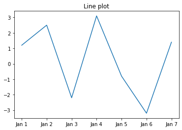

```python
%matplotlib inline

s3 = Series([1.2,2.5,-2.2,3.1,-0.8,-3.2,1.4],
            index = ['Jan 1','Jan 2','Jan 3','Jan 4','Jan 5','Jan 6','Jan 7'])
s3.plot(kind='line', title='Line plot')
```

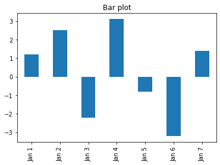

```python
s3.plot(kind='bar', title='Bar plot')
```

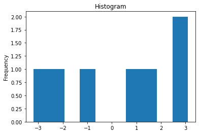

```python
s3.plot(kind='hist', title = 'Histogram')
```

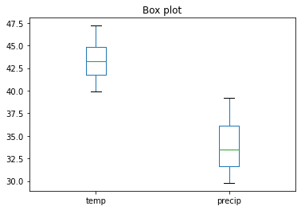

```python
tuplelist = [(2011,45.1,32.4),(2012,42.4,34.5),(2013,47.2,39.2),
              (2014,44.2,31.4),(2015,39.9,29.8),(2016,41.5,36.7)]
columnNames = ['year','temp','precip']
weatherData = DataFrame(tuplelist, columns=columnNames)
weatherData[['temp','precip']].plot(kind='box', title='Box plot')
```